# RNA Sequencing of the Human Milk Fat Layer Transcriptome Reveals Distinct Gene Expression Profiles at Three Stages of Lactation

Nikola Panajotovikj, Ester Muñoz del Campo, Marko Ludaic

Universitat Pompeu Fabra

2023-06-13

# 1 Introduction

Because of the numerous benefits breastfeeding provides, it’s recommended that infants be exclusively breastfed for the first 6 months with continued breastfeeding for at least 1 year. However lactation is not achieved in all mothers and the physiology of this process remains poorly understood. This is because of questions related to the ethics of performing tests or extracting tissues from lactating mother.

So, an interesting alternative has been proposed – human milk secreted during lactation is a rich source of mammary epithelial cell RNA. About 3–8% of human milk fat globules contain mammary epithelial cell cytoplasmic remnants, including RNA, captured during milk fat globule formation and secretion

Previous to this research, there has been attempt to undestand the human milk fat layer transcriptome with microarray techniques. This paper analyses the transcriptome with RNA-seq which, compared to microarray, has highly sensitive detail, can accurately quantify both very low and very high abundance transcripts, as well as detect novel transcripts.

The authors of this paper (Lemay et al. 2013), furthermore, suggest that the constitution of the human milk is not dependent on the days postpartum, which is the measure typically used by lactation researchers to categorize lactation stage. Rather, they state that compared to other factors such as subject, washing protocol, or time of collection, biochemically defined lactation stage (i.e., Na:K) has the largest effect on the transcriptome. So they categorise the samples as: “colostral” if Na:K >= 2.0; and as “transitional” if Na:K < 2.0; “mature” if Na:K < 0.6 .

The three main challanges of this paper are:

- because of the sample extraction, it is unknown if the milk fat layer yields RNA purely of mammary epithelial cell origin, or if RNA from non-mammary epithelial sources is also present in the milk fat layer obtained from colostrum, transitional, or mature human milk,
- because of the body heat and the environment of the milk, the RNA might end up being degraded (low RIN values),
- because this is a study of patients who would agree to participate after just having gone through giving birth and have to fulfill some criteria, the sample size is very small which is something that really influences the information that can be extracted and extrapolated from this sample group - the result of bias of such a small sample group is really apparent in the MA-plots

# 2 Quality assessment

## 2.1 Data import and cleaning

We start importing the raw table of counts.

```r
library(SummarizedExperiment)
se <- readRDS(file.path(system.file("extdata", package="IEOproject"), "GSE45669.rds"))
#se <- readRDS("../inst/extdata/GSE45669.rds")

se
class: RangedSummarizedExperiment
dim: 25118 16
metadata(4): experimentData annotation ensemblVersion urlProcessedData
assays(1): counts
rownames(25118): 1 10 ... 9994 9997
rowData names(5): gene_id gene_biotype description gene_id_version
  symbol
colnames(16): SRR801690 SRR801691 ... SRR801704 SRR801705
colData names(37): title geo_accession ... lactation stage:ch1 subject
  id:ch1
```

We have 25118 genes by 16 samples. From the first row and column names shown by the object, we can figure out that genes are defined by [Entrez](https://www.ncbi.nlm.nih.gov/gene) (Maglott et al. 2010) identifiers and samples by Sequence Read Archive Run ([SRR](https://www.ncbi.nlm.nih.gov/books/NBK56913/#search.what_do_the_different_sra_accessi)) identifiers.

Regarding the samples, we can see that tey are few, so the analysis results quality will be likely affected by this fact. It is important to keep it in mind along the process.

The row data in this object contains information about the profiled genes.

```r
head(rowData(se))
DataFrame with 6 rows and 5 columns
                  gene_id   gene_biotype            description
              <character>    <character>            <character>
1         ENSG00000121410 protein_coding alpha-1-B glycoprote..
10        ENSG00000156006 protein_coding N-acetyltransferase ..
100       ENSG00000196839 protein_coding adenosine deaminase ..
1000      ENSG00000170558 protein_coding cadherin 2 [Source:H..
10000     ENSG00000117020 protein_coding AKT serine/threonine..
100008586 ENSG00000236362 protein_coding G antigen 12F [Sourc..
             gene_id_version      symbol
                 <character> <character>
1         ENSG00000121410.11        A1BG
10         ENSG00000156006.4        NAT2
100       ENSG00000196839.12         ADA
1000       ENSG00000170558.8        CDH2
10000     ENSG00000117020.16        AKT3
100008586  ENSG00000236362.8     GAGE12F
```

Among this information, the gene symbol and description are potentially useful for interpreting results of, for instance, a differential expression analysis. Let’s explore now the column (phenotypic) data.

```r
dim(colData(se))
[1] 16 37
head(colData(se), n=3)
DataFrame with 3 rows and 37 columns
                   title geo_accession                status submission_date
             <character>   <character>           <character>     <character>
SRR801690 154-D_RNA_c0_0    GSM1111646 Public on Jul 22 2013     Apr 01 2013
SRR801691 158-1_RNA_c0_0    GSM1111647 Public on Jul 22 2013     Apr 01 2013
SRR801692 160-J_RNA_c0_2    GSM1111648 Public on Jul 22 2013     Apr 01 2013
          last_update_date        type channel_count source_name_ch1
               <character> <character>   <character>     <character>
SRR801690      May 15 2019         SRA             1  Milk Fat Layer
SRR801691      May 15 2019         SRA             1  Milk Fat Layer
SRR801692      May 15 2019         SRA             1  Milk Fat Layer
          organism_ch1 characteristics_ch1  characteristics_ch1.1
           <character>         <character>            <character>
SRR801690 Homo sapiens     subject id: 154 lactation stage: Tra..
SRR801691 Homo sapiens     subject id: 158 lactation stage: Tra..
SRR801692 Homo sapiens     subject id: 160 lactation stage: Tra..
           characteristics_ch1.2 molecule_ch1   extract_protocol_ch1
                     <character>  <character>            <character>
SRR801690 extraction protocol:..    polyA RNA Soft Spin: Whole mil..
SRR801691 extraction protocol:..    polyA RNA Soft Spin: Whole mil..
SRR801692 extraction protocol:..    polyA RNA Soft Spin: Whole mil..
          extract_protocol_ch1.1 extract_protocol_ch1.2 extract_protocol_ch1.3
                     <character>            <character>            <character>
SRR801690 Hard Spin: Whole mil.. Wash: After a hard s.. RNA Isolation: Total..
SRR801691 Hard Spin: Whole mil.. Wash: After a hard s.. RNA Isolation: Total..
SRR801692 Hard Spin: Whole mil.. Wash: After a hard s.. RNA Isolation: Total..
          extract_protocol_ch1.4   taxid_ch1        data_processing
                     <character> <character>            <character>
SRR801690 RNA libraries were p..        9606 Basecalls performed ..
SRR801691 RNA libraries were p..        9606 Basecalls performed ..
SRR801692 RNA libraries were p..        9606 Basecalls performed ..
               data_processing.1      data_processing.2      data_processing.3
                     <character>            <character>            <character>
SRR801690 Reads mapped to the .. Mapped reads were in.. Normalized transcrip..
SRR801691 Reads mapped to the .. Mapped reads were in.. Normalized transcrip..
SRR801692 Reads mapped to the .. Mapped reads were in.. Normalized transcrip..
           data_processing.4      data_processing.5 platform_id data_row_count
                 <character>            <character> <character>    <character>
SRR801690 Genome_build: hg19 Supplementary_files_..    GPL11154              0
SRR801691 Genome_build: hg19 Supplementary_files_..    GPL11154              0
SRR801692 Genome_build: hg19 Supplementary_files_..    GPL11154              0
             instrument_model library_selection library_source library_strategy
                  <character>       <character>    <character>      <character>
SRR801690 Illumina HiSeq 2000              cDNA transcriptomic          RNA-Seq
SRR801691 Illumina HiSeq 2000              cDNA transcriptomic          RNA-Seq
SRR801692 Illumina HiSeq 2000              cDNA transcriptomic          RNA-Seq
                        relation             relation.1 supplementary_file_1
                     <character>            <character>          <character>
SRR801690 SRA: https://www.ncb.. BioSample: https://w..                 NONE
SRR801691 SRA: https://www.ncb.. BioSample: https://w..                 NONE
SRR801692 SRA: https://www.ncb.. BioSample: https://w..                 NONE
          extraction protocol:ch1 lactation stage:ch1 subject id:ch1
                      <character>         <character>    <character>
SRR801690     Soft spin, Unwashed        Transitional            154
SRR801691     Hard spin, Unwashed        Transitional            158
SRR801692  Hard spin, Washed once        Transitional            160
```

We have a total of 37 phenotypic variables. The second column `geo_accession` contains GEO Sample Accession Number ([GSM](https://www.ncbi.nlm.nih.gov/geo/info/overview.html)) identifiers. GSM identifiers define individual samples, understood in our context as individual sources of RNA. In this dataset, there are no technical replicates.

To proceed further exploring this dataset, we are going to use the edgeR package and build a `DGEList` object, incorporating the gene metadata, which includes the gene symbol.

```r
library(IEOproject)
library(edgeR)

dge <- DGEList(counts=assays(se)$counts, genes=rowData(se))
dim(dge)
[1] 25118    16
```

Calculate $\log_2$ CPM units of expression and put them as an additional assay element to ease their manipulation.

```r
assays(se)$logCPM <- cpm(dge, log=TRUE,  prior.count=0.25)
assays(se)$logCPM[1:5, 1:5]
       SRR801690  SRR801691 SRR801692 SRR801693  SRR801694
1     -7.2388751 -7.2388751 -4.648112 -3.248656 -7.2388751
10    -4.3144409 -2.1092005 -7.238875 -7.238875 -0.8796359
100    2.1843310 -0.7364584  2.080955  2.589905  0.7185524
1000  -7.2388751 -7.2388751 -7.238875 -7.238875 -0.9566625
10000 -0.5045971 -3.4982615 -1.559628  4.905827 -0.9566625
```

In the codeblock below, we loop through all the columns of the phenotype table to see if there are any variables for which there are groups (batch-effect):

```r
# loop over the columns and count unique values
for (col in names(colData(se))) {
  unique_vals <- unique(colData(se)[[col]])
  if (any(length(unique_vals) %in% c(1, 16))) {
    next # skip to the next column
  } else {
    counts <- table(colData(se)[[col]])
    cat(paste0("Column '", col, "' has ", length(unique_vals), " unique values:\n"))
    print(counts)
  }
}
Column 'characteristics_ch1' has 11 unique values:

subject id: 153 subject id: 154 subject id: 158 subject id: 160 subject id: 168
              1               1               1               1               1
subject id: 174 subject id: 179 subject id: 183 subject id: 187 subject id: 188
              1               3               3               2               1
subject id: 359
              1
Column 'characteristics_ch1.1' has 3 unique values:

   lactation stage: Colostrum       lactation stage: Mature
                            3                             8
lactation stage: Transitional
                            5
Column 'characteristics_ch1.2' has 4 unique values:

    extraction protocol: Hard spin, Unwashed
                                           5
 extraction protocol: Hard spin, Washed once
                                           6
extraction protocol: Hard spin, Washed twice
                                           3
    extraction protocol: Soft spin, Unwashed
                                           2
Column 'extraction protocol:ch1' has 4 unique values:

    Hard spin, Unwashed  Hard spin, Washed once Hard spin, Washed twice
                      5                       6                       3
    Soft spin, Unwashed
                      2
Column 'lactation stage:ch1' has 3 unique values:

   Colostrum       Mature Transitional
           3            8            5
Column 'subject id:ch1' has 11 unique values:

153 154 158 160 168 174 179 183 187 188 359
  1   1   1   1   1   1   3   3   2   1   1
```

To facilitate handling these variables we are going to recode them as follows.

First we replace spaces in column names.

```r
# simpler names
names(colData(se))[37] <- "id"
names(colData(se))[36] <- "lacStage"
names(colData(se))[35] <- "protocol"

# creating factors
colData(se)$idFac <- factor(colData(se)$id)
# colData(se)$lacStageFac <- factor(colData(se)$lacStage)
colData(se)$lacStageFac <- factor(colData(se)$lacStage,
                                  levels = c("Colostrum", "Transitional", "Mature"),
                                  labels = c(1, 2, 3))

#colData(se)$protocolFac <- factor(colData(se)$protocol)
colData(se)$protocolFac <- factor(colData(se)$protocol,
                                  levels = c("Soft spin, Unwashed", "Hard spin, Unwashed", "Hard spin, Washed once", "Hard spin, Washed twice"),
                                  labels = c(1, 2, 3, 4 ))
```

In Table 1 below, we show this variable jointly with lactation stage and protocol to try to gather as much understanding as possible on the underlying experimental design.

Table 1: Phenotypic variables.

| Patient | lacStage | protocol |
| --- | --- | --- |
| 154 | Transitional | Soft spin, Unwashed |
| 158 | Transitional | Hard spin, Unwashed |
| 160 | Transitional | Hard spin, Washed once |
| 187 | Colostrum | Hard spin, Unwashed |
| 179 | Transitional | Hard spin, Washed once |
| 183 | Colostrum | Hard spin, Washed once |
| 187 | Colostrum | Hard spin, Washed once |
| 188 | Transitional | Hard spin, Washed once |
| 179 | Mature | Hard spin, Unwashed |
| 183 | Mature | Hard spin, Unwashed |
| 168 | Mature | Hard spin, Washed twice |
| 359 | Mature | Soft spin, Unwashed |
| 179 | Mature | Hard spin, Washed twice |
| 183 | Mature | Hard spin, Washed twice |
| 174 | Mature | Hard spin, Washed once |
| 153 | Mature | Hard spin, Unwashed |

## 2.2 Sequencing depth

Let’s examine the sequencing depth in terms of total number of sequence read counts mapped to the genome per sample. The figure below shows the sequencing depth per sample, also known as library sizes, in increasing order.

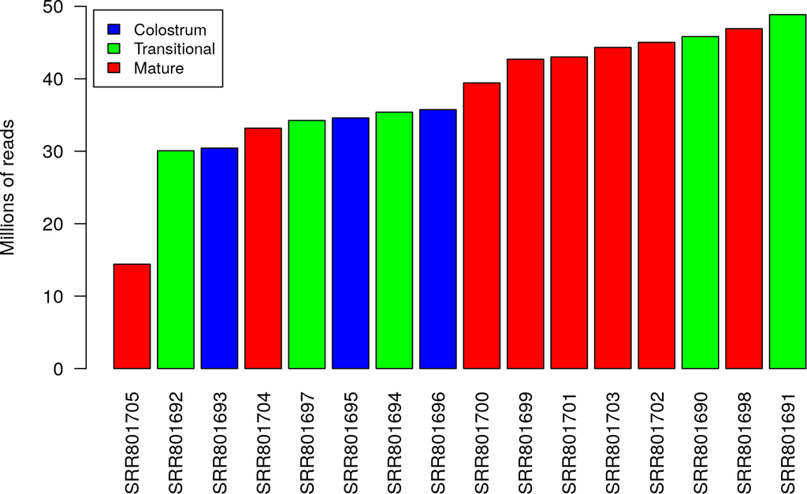

From the plot above we don’t notice any biases related to the different lactation stages (colors). The only thing that stands out is SRR801705 as having very low sequencing depth. In the later part of the analysis we will remove it from the analysis, since it seems to be an error with the sample sequencing.

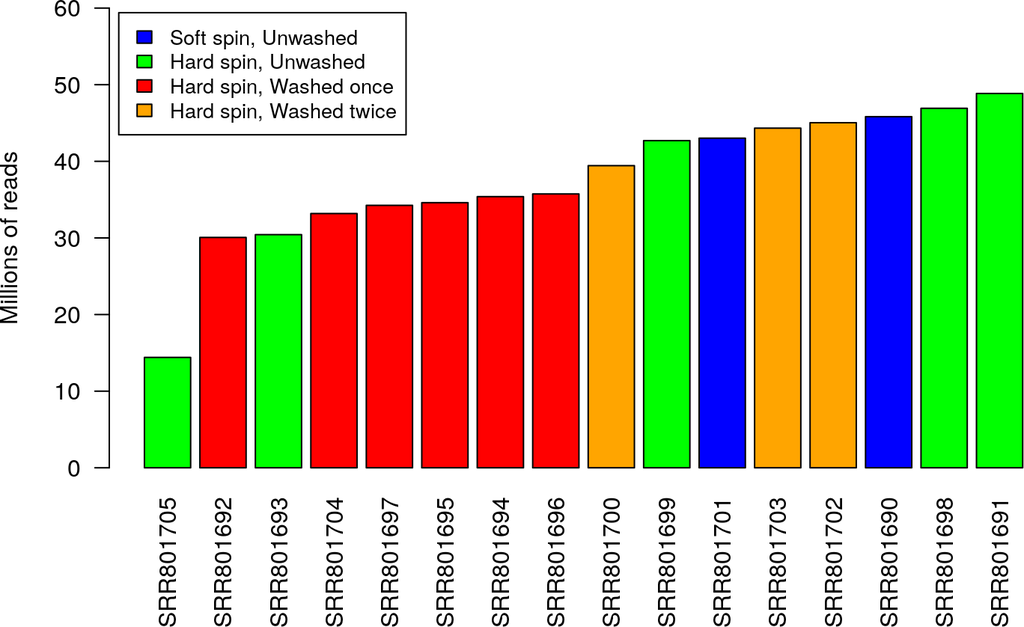

From the plot above we do not see any bias. The “Hard spin, Washed once” groups together but there doesn’t seem to be a significantly extreme difference in their sequencing depth. We will further analyze this with a clustering approach.

## 2.3 Distribution of expression levels among samples

Figure 1 below shows the distribution of expression values per sample in logarithmic CPM units of expression.

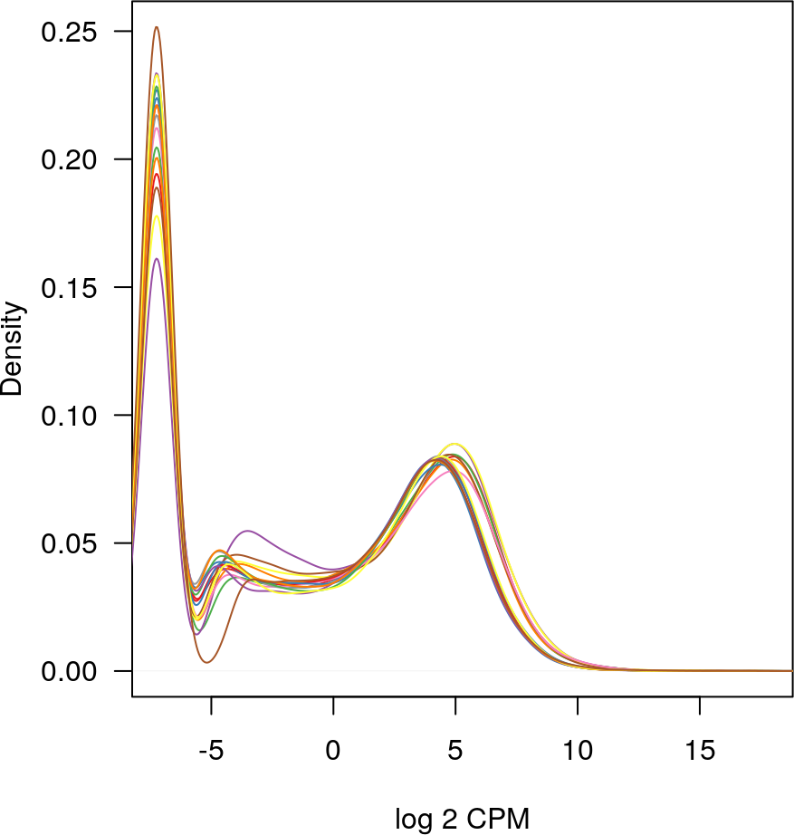

Figure 1: Non-parametric density distribution of expression profiles per sample

There are no substantial differences between the samples in the distribution of expression values.

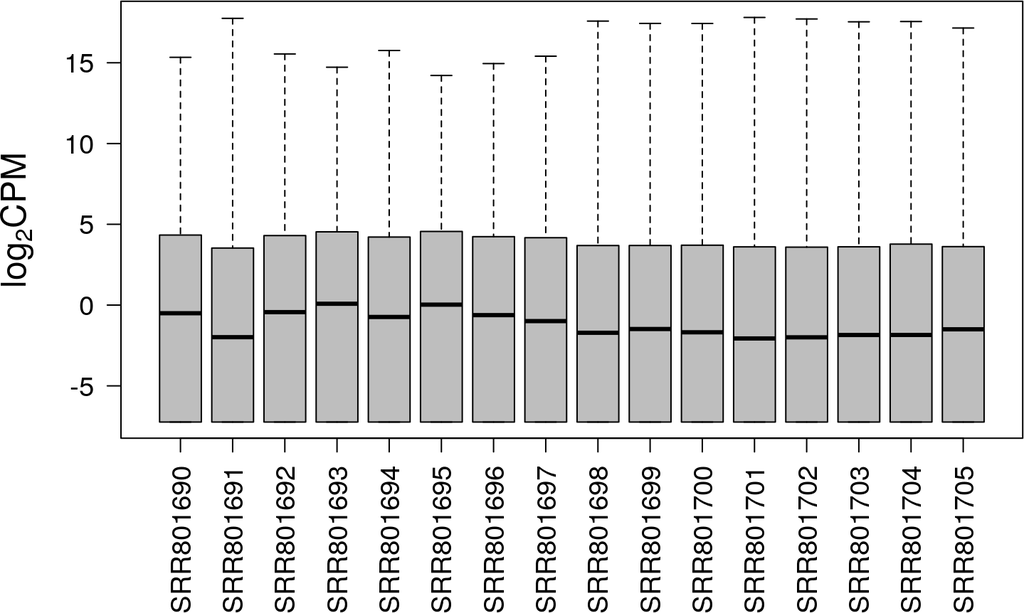

```r
par(mar=c(7, 5, 2, 2))
boxplot(assays(se)$logCPM, col="gray", ylab=expression(log[2] * "CPM"),
cex.axis=1.2, cex.lab=1.5, las=2)
```

In the previous plots we see that the SRR801705 sample does not behave differently than the rest, but this is due to the fact that we are now considering the counts per million (CPM), and what is wrong about that sample is the sequencing depth, so still we will exclude it from the analysis.

## 2.4 Distribution of expression levels among genes

Let’s calculate now the average expression per gene through all the samples. Figure 2 shows the distribution of those values across genes.

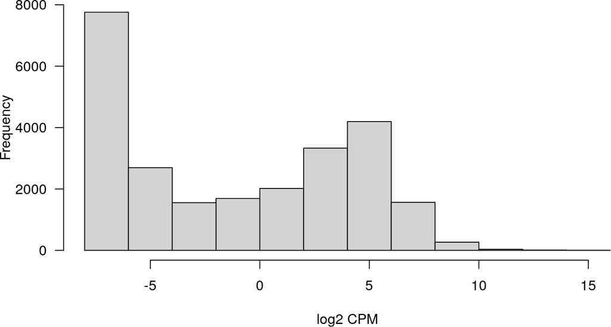

Figure 2: Distribution of average expression level per gene

As expected, we have two modes, one for genes that are lowly expressed in nearly all samples and another for genes with some detectable levels of expression across a number of samples.

## 2.5 Filtering of lowly-expressed genes

In the paper, transcript abundances were estimated as FPKMs (fragments per kilobase of exon per million fragments mapped) using Cufflinks. Genes with a mean expression level less than 0.01 FPKM (manually set) across all time points and all samples were excluded from further analysis.

In our analysis, we use CPM (counts per million) and after some trial and error we found that the best cutoff value from the cpm would be arround 0.1.

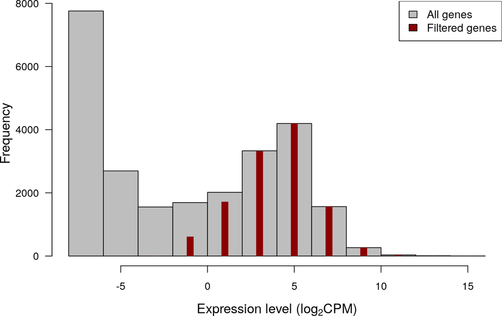

```r
#cpmcutoff <- round(10/min(dge_sample_filtered$sample$lib.size/1e6), digits=1)
cpmcutoff <- 0.1
print(cpmcutoff)
[1] 0.1

#nsamplescutoff <- min(table(se_sample_filtered$protocolFac))
nsamplescutoff<- 15
print(nsamplescutoff)
[1] 15

mask <- rowSums(cpm(dge_sample_filtered) > cpmcutoff) >= nsamplescutoff

se.filt <- se_sample_filtered[mask, ]
dim(se.filt)
[1] 11729    15
dge.filt <- dge_sample_filtered[mask, ]
dim(dge.filt)
[1] 11729    15



par(mar=c(4, 5, 1, 1))

h <- hist(avgexp, xlab=expression("Expression level (" * log[2] * "CPM)"),
          main="", las=1, col="grey", cex.axis=0.95, cex.lab=1.2)

x <- cut(rowMeans(assays(se.filt)$logCPM), breaks=h$breaks)

lines(h$mids, table(x), type="h", lwd=10, lend=1, col="darkred")

legend("topright", c("All genes", "Filtered genes"), fill=c("grey", "darkred"))
```

We are left with 11729 genes.

## 2.6 Normalization

We calculate now the normalization factors on the filtered expression data set.

```r
dge.filt <- calcNormFactors(dge.filt)
```

Replace the raw log2 CPM units in the corresponding assay element of the `SummarizedExperiment` object, by the normalized ones.

```r
assays(se.filt)$logCPM <- cpm(dge.filt, log=TRUE,
                              normalized.lib.sizes=TRUE)
```

## 2.7 MA-plots

We examine now the MA-plots of the normalized expression profiles in Figure 3.

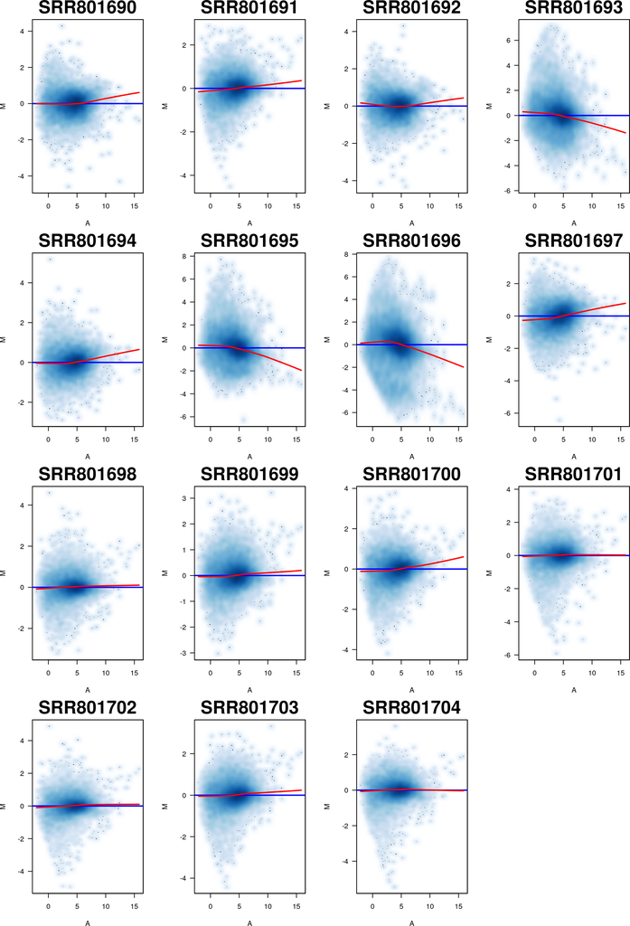

Figure 3: MA-plots of filtered and normalized expression values

A number of samples display some expression-level dependent bias. For cases in which this occurs at the low-end of the expression level, one solution could be to have a more stringent filter on minimum expression using a grouping with more samples per group, for instance. However, considering the low number of samples we are working with we decide to keep it this way. Of course, we should keep an eye on samples with these biases in case they also display other unexpected features, because then we might consider removing them.

## 2.8 Experimental design and batch identification

Here try to understand the underlying experimental design. We take a look at the combination of sample preparation protocol and lactation stage.

```r
table(se.filt$lacStageFac, se.filt$protocolFac)

    1 2 3 4
  1 0 1 2 0
  2 1 1 3 0
  3 1 2 1 3
```

We can see that not all the protocols have been used in all lactation stages, but still the distribution is quite balanced and the number of missing combinations is not critical for the analysis. This means that there are more chances that the differences observed are due to biological reasons rather than technical.

We examine now how samples group together by hierarchical clustering and multidimensional scaling, annotating lactation stage (number) and protocol(color) for each sample. We calculate again log CPM values with a high prior count(3) to moderate extreme fold-changes produced by low counts. The resulting dendrogram is shown in Figure 4.

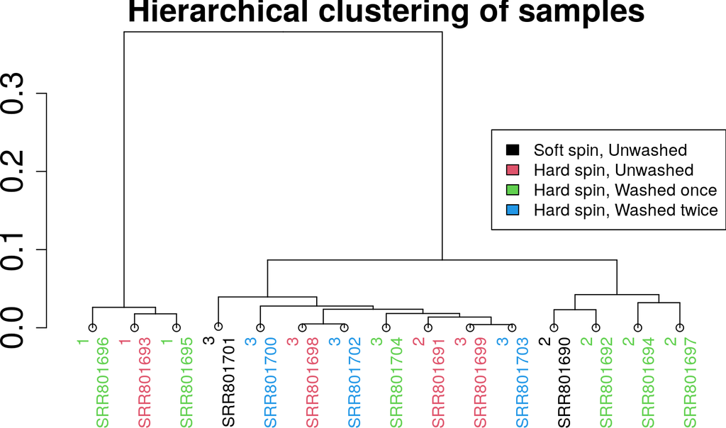

Figure 4: Hierarchical clustering of the samples  
Labels correspond to treatment and sample identifer, while colors indicate sample group.

We can see that the samples do not seem to group by protocol. Now we will test if they group by lactation stage in the Figure 5.

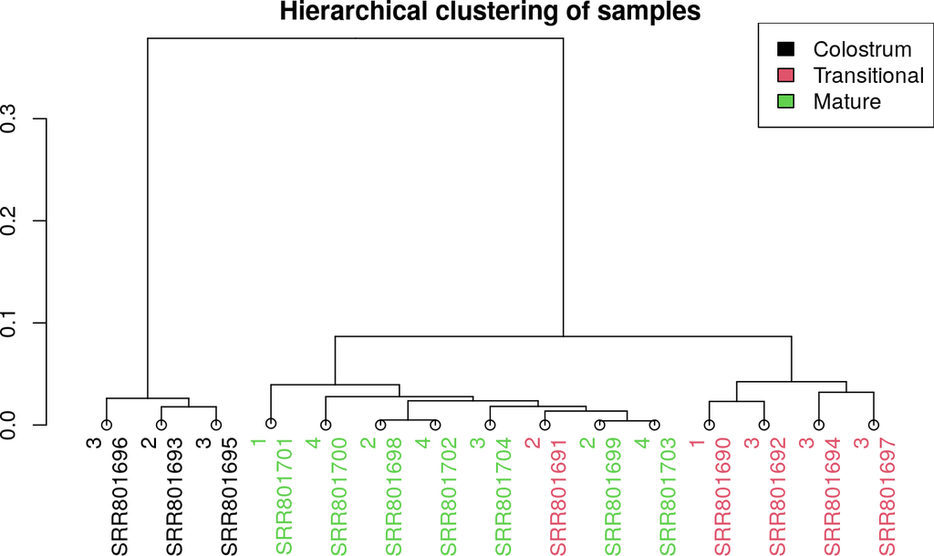

Figure 5: Hierarchical clustering of the samples  
Labels correspond to treatment and sample identifer, while colors indicate sample group.

We can clearly see that the samples group by lactation stage in the clustering, since each cluster contains samples from a lactation stage, with the only exception of the sample SRR801691.

Next we will perform an MDS plot using the names of the lactation stages and colors according to protocol in order to ratify if they in deed group by lactation stage (Figure 6).

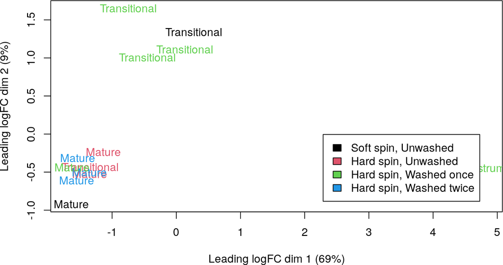

Figure 6: Figure S7: Multidimensional scaling plot of the samples  
Labels correspond to treatment and colors indicate sample group.

In fact, the samples group by lactation stage.

# 3 Differential expression

We now perform an analysis to observe differential expressed (DE) genes by excluding each of the 3 lactation stages one by one. This is also the approach that is described in the paper.

## 3.1 Analysing Fold-Change

```r
Col_exp <- rowMeans(logCPM[, se_sample_filtered$lacStage=="Colostrum"])
Tra_exp <- rowMeans(logCPM[, se_sample_filtered$lacStage=="Transitional"])
Mat_exp <- rowMeans(logCPM[, se_sample_filtered$lacStage=="Mature"])
```

In Figure 7 we analyse the fold-change for the Colostral and Transitional stage. Given that the sample size is only 16 (actually 15, given that we filter 1 because of low quality).

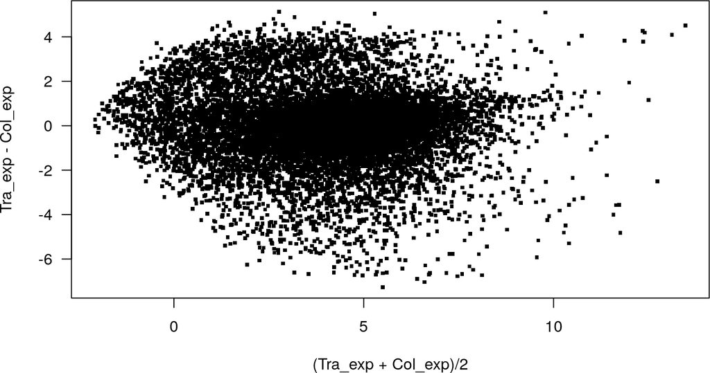

Figure 7: A plot analysing the difference in expression between Colostral and Transitional stage

```r
plot((Tra_exp+Col_exp)/2, Tra_exp-Col_exp, pch=".", cex=4, las=1)
```

In Figure 8 we analyse the fold-change for the Colostral and Mature stage.

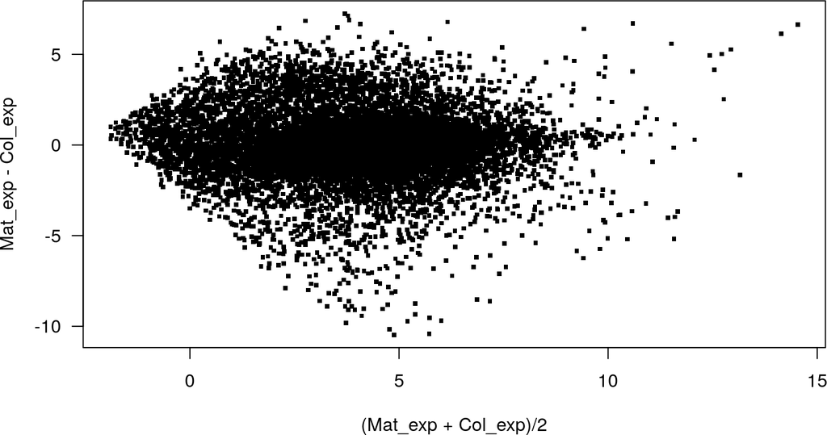

Figure 8: A plot analysing the difference in expression between Colostral and Mature stage

```r
plot((Mat_exp+Col_exp)/2, Mat_exp-Col_exp, pch=".", cex=4, las=1)
```

In Figure 9 we analyse the fold-change for the Transitional and Mature stage.

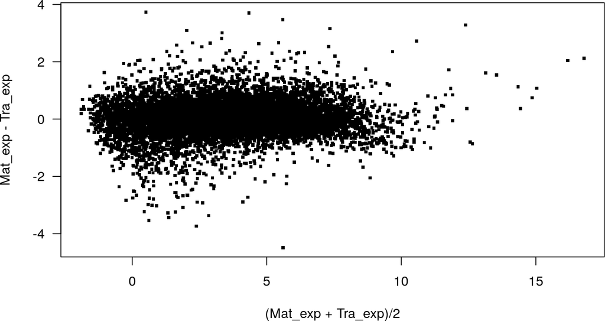

Figure 9: A plot analysing the difference in expression between Transitional and Mature stage

```r
plot((Mat_exp+Tra_exp)/2, Mat_exp-Tra_exp, pch=".", cex=4, las=1)
```

## 3.2 Performing Differential Expression

First, we will observed stage 1 and 2 that correspond to colostrum and transitional stage, leaving out the maturation stage (stage 3). Afterwards, we will exclude colostrum stage (stage 1) and finally we will exclude transitional stage (stage 2). We do the same scheme later for the functional enrichment analysis.

It’s worth mentioning that because with the noise from the low sample size, we end up with a lot of DE genes. To reduce the number of genes and to increase the validity of the DE analysis we perform two DE analysis: one with SVA and one with limma - then we extract the intersection of both those sets. We use this later on for the functional enrichment.

```r
library(sva)
library(limma)
```

## 3.3 DE Between Colostrum and Transitional

Checking the distribution of differentially expressed genes. In Figure 10 we analyse the differential expression between the Colostrum and Transitional stage.

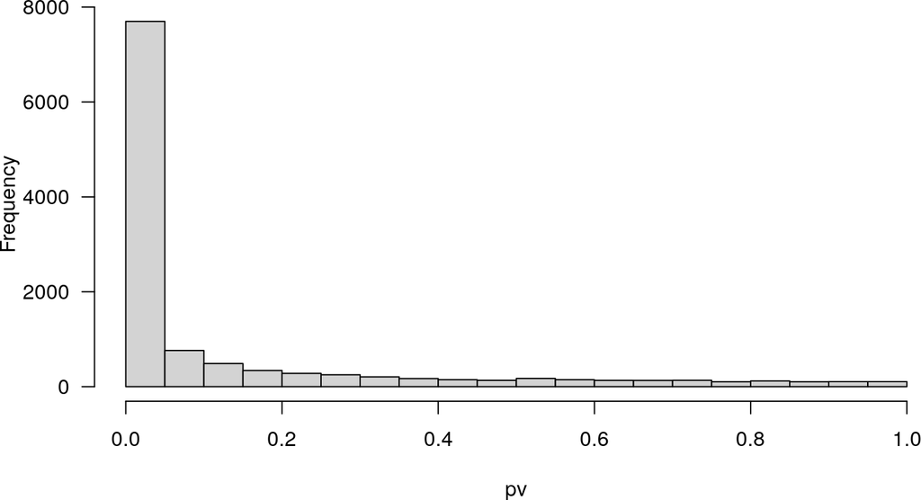

Figure 10: P-value diagnostic plot for differental expression between Colostrum and Transitional

```r
se.filt.all <- se.filt[,se.filt$lacStageFac!=3]
se.filt.all$stage <- droplevels(se.filt.all$lacStageFac)

mod <- model.matrix(~ se.filt.all$stage, colData(se.filt.all))
mod0 <- model.matrix(~ 1, colData(se.filt.all))

pv <- f.pvalue(assays(se.filt.all)$logCPM, mod, mod0)
hist(pv, main="", las=1)
```

```r
mask <- p.adjust(pv, method="fdr") < 0.1
DEgenesEGs <- names(pv)[mask]
DEgenesSyms <- mcols(se.filt)[DEgenesEGs, "symbol"]
DEgenesPvalue <- pv[mask]
DEgenesDesc <- mcols(se.filt)[DEgenesEGs, "description"]
DEgenesDesc <- sub(" \\[.+\\]", "", DEgenesDesc)
DEgenesTab <- data.frame(EntrezID=DEgenesEGs,
                         Symbol=DEgenesSyms,
                         Description=DEgenesDesc,
                         "P value"=DEgenesPvalue,
                         stringsAsFactors=FALSE, check.names=FALSE)
DEgenesTab <- DEgenesTab[order(DEgenesTab[["P value"]]), ]
```

### 3.3.1 Volcano plot

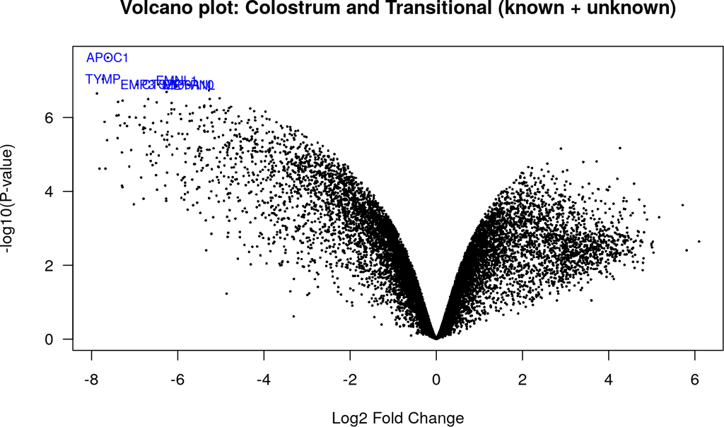

```r
sv <- sva(assays(se.filt.all)$logCPM, mod=mod, mod0=mod0)
Number of significant surrogate variables is:  3
Iteration (out of 5 ):1  2  3  4  5
mod <- cbind(mod, sv$sv)
colnames(mod) <- c(colnames(mod)[1:2], paste0("SV", 1:sv$n))
fit3 <- lmFit(assays(se.filt.all)$logCPM, mod)
fit3 <- eBayes(fit3)
tt3 <- topTable(fit3, coef=2, n=Inf)

DEgenes_no3 <- rownames(tt3)[tt3$adj.P.Val < 0.1]
sort(table(tt3[DEgenes_no3, "chr"]), decreasing=TRUE)
integer(0)
res3 <- decideTests(fit3, p.value=0.1)

genesmd <- data.frame(chr=as.character(seqnames(rowRanges(se.filt.all))), symbol=rowData(se.filt.all)[, 5], stringsAsFactors=FALSE)
fit3$genes <- genesmd

volcanoplot(fit3, coef=2, highlight=7, names=fit3$genes$symbol, main="Volcano plot: Colostrum and Transitional (known + unknown)", las=1)
```

```r
top7_no3 <- order(fit3$lods[,2], decreasing=TRUE)
print("The top 7 genes are:")
[1] "The top 7 genes are:"
top7_no3 <- fit3$genes$symbol[top7_no3][1:7]
top7_no3
[1] "APOC1"   "TYMP"    "FMNL1"   "S100A10" "EMP3"    "CTSZ"    "METRNL"
```

```r
mask <- DEgenesTab$EntrezID %in% DEgenes_no3
DEgenesTab <- DEgenesTab[mask,]
```

In the table 2 the DE genes with lowest p-values are displayed:

|  | EntrezID | Symbol | Description | P value |
| --- | --- | --- | --- | --- |
| 10672 | 10672 | GNA13 | G protein subunit alpha 13 | 0e+00 |
| 116985 | 116985 | ARAP1 | ArfGAP with RhoGAP domain, ankyrin repeat and PH domain 1 | 1e-07 |
| 144110 | 144110 | TMEM86A | transmembrane protein 86A | 1e-07 |
| 391 | 391 | RHOG | ras homolog family member G | 1e-07 |
| 1200 | 1200 | TPP1 | tripeptidyl peptidase 1 | 1e-07 |
| 54978 | 54978 | SLC35F6 | solute carrier family 35 member F6 | 1e-07 |
| 155400 | 155400 | NSUN5P1 | NOP2/Sun RNA methyltransferase family member 5 pseudogene 1 | 1e-07 |
| 5538 | 5538 | PPT1 | palmitoyl-protein thioesterase 1 | 1e-07 |
| 4286 | 4286 | MITF | melanogenesis associated transcription factor | 1e-07 |
| 55604 | 55604 | CARMIL1 | capping protein regulator and myosin 1 linker 1 | 2e-07 |

## 3.4 DE Between Transitional and Mature

Checking the distribution of differentially expressed genes:

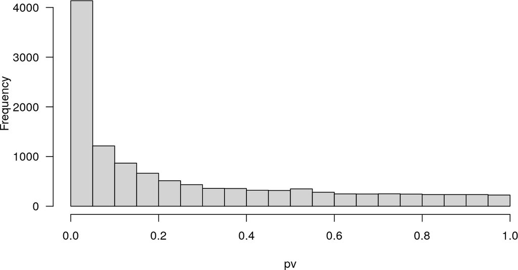

```r
se.filt.all <- se.filt[,se.filt$lacStageFac!=1]
se.filt.all$stage <- droplevels(se.filt.all$lacStageFac)

mod <- model.matrix(~ se.filt.all$stage,
                    colData(se.filt.all))
mod0 <- model.matrix(~ 1, colData(se.filt.all))


pv <- f.pvalue(assays(se.filt.all)$logCPM, mod, mod0)
#sum(p.adjust(pv, method="fdr") < 0.05)
#sum(p.adjust(pv, method="fdr") < 0.1)
hist(pv, main="", las=1)
```

```r
mask <- p.adjust(pv, method="fdr") < 0.1
DEgenesEGs <- names(pv)[mask]
DEgenesSyms <- mcols(se.filt)[DEgenesEGs, "symbol"]
DEgenesPvalue <- pv[mask]
DEgenesDesc <- mcols(se.filt)[DEgenesEGs, "description"]
DEgenesDesc <- sub(" \\[.+\\]", "", DEgenesDesc)
DEgenesTab <- data.frame(EntrezID=DEgenesEGs,
                         Symbol=DEgenesSyms,
                         Description=DEgenesDesc,
                         "P value"=DEgenesPvalue,
                         stringsAsFactors=FALSE, check.names=FALSE)
DEgenesTab <- DEgenesTab[order(DEgenesTab[["P value"]]), ] ## order by p-value
rownames(DEgenesTab) <- 1:nrow(DEgenesTab)
```

### 3.4.1 Volcano plot

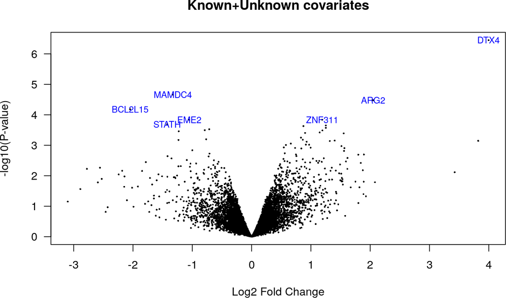

```r
sv <- sva(assays(se.filt.all)$logCPM, mod=mod, mod0=mod0)
Number of significant surrogate variables is:  4
Iteration (out of 5 ):1  2  3  4  5
mod <- cbind(mod, sv$sv)
colnames(mod) <- c(colnames(mod)[1:2], paste0("SV", 1:sv$n))
fit3 <- lmFit(assays(se.filt.all)$logCPM, mod)
fit3 <- eBayes(fit3)
tt3 <- topTable(fit3, coef=2, n=Inf)
DEgenes_no1 <- rownames(tt3)[tt3$adj.P.Val < 0.1]
sort(table(tt3[DEgenes_no1, "chr"]), decreasing=TRUE)
integer(0)
res3 <- decideTests(fit3, p.value=0.1)
genesmd <- data.frame(chr=as.character(seqnames(rowRanges(se.filt.all))), symbol=rowData(se.filt.all)[, 5], stringsAsFactors=FALSE)
fit3$genes <- genesmd
volcanoplot(fit3, coef=2, highlight=7, names=fit3$genes$symbol, main="Known+Unknown covariates", las=1)
```

```r
top7_no1 <- order(fit3$lods[,2], decreasing=TRUE)
print("The top 7 genes are:")
[1] "The top 7 genes are:"
top7_no1 <- fit3$genes$symbol[top7_no1][1:7]
top7_no1
[1] "DTX4"    "MAMDC4"  "ARG2"    "BCL2L15" "ZNF311"  "EME2"    "STATH"
```

```r
mask <- DEgenesTab$EntrezID %in% DEgenes_no3
DEgenesTab <- DEgenesTab[mask,]
```

In the table 3 the DE genes with lowest p-values are displayed:

|  | EntrezID | Symbol | Description | P value |
| --- | --- | --- | --- | --- |
| 2 | 5493 | PPL | periplakin | 4.70e-06 |
| 4 | 117583 | PARD3B | par-3 family cell polarity regulator beta | 1.32e-05 |
| 5 | 79871 | RPAP2 | RNA polymerase II associated protein 2 | 1.39e-05 |
| 7 | 79071 | ELOVL6 | ELOVL fatty acid elongase 6 | 2.26e-05 |
| 8 | 285362 | SUMF1 | sulfatase modifying factor 1 | 2.74e-05 |
| 10 | 5565 | PRKAB2 | protein kinase AMP-activated non-catalytic subunit beta 2 | 3.36e-05 |
| 12 | 6235 | RPS29 | ribosomal protein S29 | 3.87e-05 |
| 13 | 307 | ANXA4 | annexin A4 | 4.12e-05 |
| 14 | 1457 | CSNK2A1 | casein kinase 2 alpha 1 | 4.32e-05 |
| 16 | 282890 | ZNF311 | zinc finger protein 311 | 5.24e-05 |

## 3.5 DE Between Colostrum and Mature

Checking the distribution of differentially expressed genes:

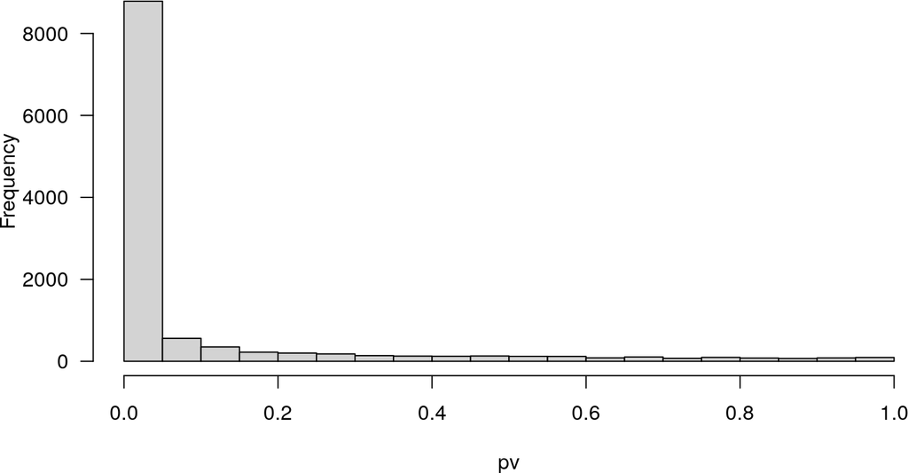

```r
se.filt.all <- se.filt[,se.filt$lacStageFac!=2]
se.filt.all$stage <- droplevels(se.filt.all$lacStageFac)

mod <- model.matrix(~ se.filt.all$stage,
                    colData(se.filt.all))
mod0 <- model.matrix(~ 1, colData(se.filt.all))


pv <- f.pvalue(assays(se.filt.all)$logCPM, mod, mod0)
#sum(p.adjust(pv, method="fdr") < 0.05)
#sum(p.adjust(pv, method="fdr") < 0.1)
hist(pv, main="", las=1)
```

```r
mask <- p.adjust(pv, method="fdr") < 0.1
DEgenesEGs <- names(pv)[mask]
DEgenesSyms <- mcols(se.filt)[DEgenesEGs, "symbol"]
DEgenesPvalue <- pv[mask]
DEgenesDesc <- mcols(se.filt)[DEgenesEGs, "description"]
DEgenesDesc <- sub(" \\[.+\\]", "", DEgenesDesc)
DEgenesTab <- data.frame(EntrezID=DEgenesEGs,
                         Symbol=DEgenesSyms,
                         Description=DEgenesDesc,
                         "P value"=DEgenesPvalue,
                         stringsAsFactors=FALSE, check.names=FALSE)
DEgenesTab <- DEgenesTab[order(DEgenesTab[["P value"]]), ] ## order by p-value
rownames(DEgenesTab) <- 1:nrow(DEgenesTab)
```

### 3.5.1 Volcano plot

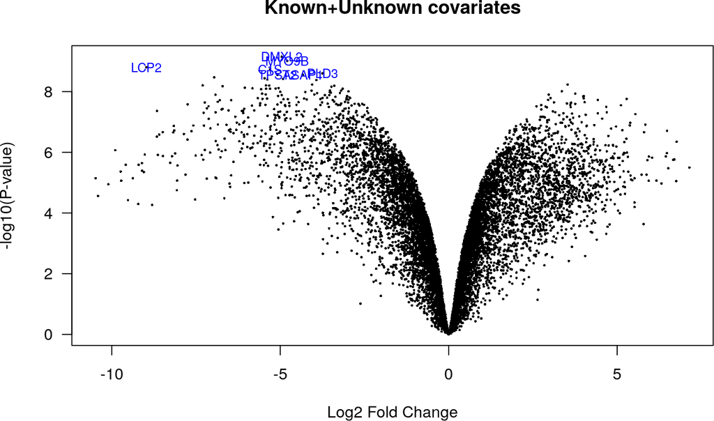

```r
sv <- sva(assays(se.filt.all)$logCPM, mod=mod, mod0=mod0)
Number of significant surrogate variables is:  4
Iteration (out of 5 ):1  2  3  4  5
mod <- cbind(mod, sv$sv)
colnames(mod) <- c(colnames(mod)[1:2], paste0("SV", 1:sv$n))
fit3 <- lmFit(assays(se.filt.all)$logCPM, mod)
fit3 <- eBayes(fit3)
tt3 <- topTable(fit3, coef=2, n=Inf)
DEgenes_no2 <- rownames(tt3)[tt3$adj.P.Val < 0.1]
sort(table(tt3[DEgenes_no2, "chr"]), decreasing=TRUE)
integer(0)
res3 <- decideTests(fit3, p.value=0.1)
genesmd <- data.frame(chr=as.character(seqnames(rowRanges(se.filt.all))), symbol=rowData(se.filt.all)[, 5], stringsAsFactors=FALSE)
fit3$genes <- genesmd
volcanoplot(fit3, coef=2, highlight=7, names=fit3$genes$symbol, main="Known+Unknown covariates", las=1)
```

```r
top7_no2 <- order(fit3$lods[,2], decreasing=TRUE)
print("The top 7 genes are:")
[1] "The top 7 genes are:"
top7_no2 <- fit3$genes$symbol[top7_no2][1:7]
top7_no2
[1] "DMXL2" "MYO9B" "LCP2"  "C1S"   "PLD3"  "ASAP1" "TPST2"
```

```r
mask <- DEgenesTab$EntrezID %in% DEgenes_no2
DEgenesTab <- DEgenesTab[mask,]
```

In the table 4 the DE genes with lowest p-values are displayed:

|  | EntrezID | Symbol | Description | P value |
| --- | --- | --- | --- | --- |
| 1 | 2889 | RAPGEF1 | Rap guanine nucleotide exchange factor 1 | 0 |
| 2 | 116985 | ARAP1 | ArfGAP with RhoGAP domain, ankyrin repeat and PH domain 1 | 0 |
| 3 | 7094 | TLN1 | talin 1 | 0 |
| 4 | 5230 | PGK1 | phosphoglycerate kinase 1 | 0 |
| 5 | 3073 | HEXA | hexosaminidase subunit alpha | 0 |
| 6 | 5777 | PTPN6 | protein tyrosine phosphatase, non-receptor type 6 | 0 |
| 7 | 3516 | RBPJ | recombination signal binding protein for immunoglobulin kappa J region | 0 |
| 8 | 23313 | KIAA0930 | KIAA0930 | 0 |
| 9 | 23646 | PLD3 | phospholipase D family member 3 | 0 |
| 10 | 5027 | P2RX7 | purinergic receptor P2X 7 | 0 |

The number of DE genes in the three comparisons above are:

- Colostral-Transitional 8028 DE genes
- Transitional-Mature 3299 DE genes
- Colostral-Mature 9151 DE genes.

As we mentioned, the sample size is quite small in our case, so that gives rise to different biases which can be dealt with using different strategies, and yielding slightly different results.

# 4 Functional analysis

Here we will do the functional analysis.

```r
library(org.Hs.eg.db)
library(GOstats)
library(KEGGREST)

geneUniverse <- rownames(se)
```

## 4.1 Between Colostrum and Transitional (no_3)

### 4.1.1 Go enrichment

```r
params <- new("GOHyperGParams", geneIds=DEgenesEGs_no3,universeGeneIds=geneUniverse, annotation="org.Hs.eg.db", ontology="BP", pvalueCutoff=0.05, testDirection="over")

conditional(params) <- TRUE
hgOverCond <- hyperGTest(params)
goresults <- summary(hgOverCond)
```

```r
mask <- goresults$OddsRatio != "Inf"
goresults <- goresults[mask, ]
goresults <- goresults[order(goresults$OddsRatio, decreasing=TRUE), ]
goresults <- goresults[goresults$Size >= 3 & goresults$Size <= 100 & goresults$Count >=25, ]
```

In the given context, “Size” refers to the total number of genes associated with a specific Gene Ontology Biological Process ID (GOBPID). It indicates the number of genes in the dataset that are related to the biological process represented by the GOBPID.

On the other hand, “Count” represents the number of genes within the dataset that were found to be associated with the given GOBPID. It indicates the number of genes in the dataset that were experimentally observed or predicted to be involved in the biological process represented by the GOBPID.

```r
geneIDs <- geneIdsByCategory(hgOverCond)[goresults$GOBPID]
geneSYMs <- sapply(geneIDs, function(id) select(org.Hs.eg.db, columns="SYMBOL", key=id, keytype="ENTREZID")$SYMBOL)
geneSYMs <- sapply(geneSYMs, paste, collapse=", ")
goresults <- cbind(goresults, Genes=geneSYMs)
rownames(goresults) <- 1:nrow(goresults)


ktab <- kable(goresults, "html", caption="GO results.")
ktab <- kable_styling(ktab, bootstrap_options=c("stripped", "hover", "responsive"), fixed_thead=TRUE)
save_kable(ktab, file="../doc/goresults_no3.html", self_contained=TRUE)

ktab <- kable(goresults[1:10, 2:7], "html", escape=FALSE, row.names=TRUE, caption=sprintf("________dasasdasddsa__________"))
kable_styling(ktab, position="center")
```

|  | Pvalue | OddsRatio | ExpCount | Count | Size | Term |
| --- | --- | --- | --- | --- | --- | --- |
| 1 | 0.0000001 | 6.911367 | 15.56195 | 32 | 39 | translational initiation |
| 2 | 0.0000006 | 5.832363 | 15.60129 | 31 | 39 | positive regulation of interferon-beta production |
| 3 | 0.0000000 | 5.128341 | 26.40219 | 51 | 66 | proton motive force-driven mitochondrial ATP synthesis |
| 4 | 0.0000000 | 4.902320 | 27.20225 | 52 | 68 | protein K48-linked ubiquitination |
| 5 | 0.0000002 | 4.634805 | 21.20175 | 40 | 53 | retrograde vesicle-mediated transport, Golgi to endoplasmic reticulum |
| 6 | 0.0000024 | 3.978944 | 20.40169 | 37 | 51 | mitochondrial electron transport, NADH to ubiquinone |
| 7 | 0.0000010 | 3.859392 | 22.80189 | 41 | 57 | protein K63-linked ubiquitination |
| 8 | 0.0000007 | 3.810264 | 24.00199 | 43 | 60 | cytoplasmic pattern recognition receptor signaling pathway |
| 9 | 0.0001176 | 3.509209 | 16.00132 | 28 | 40 | cortical actin cytoskeleton organization |
| 10 | 0.0000043 | 3.429939 | 23.60195 | 41 | 59 | mitochondrial respiratory chain complex I assembly |

### 4.1.2 KEGG enrichment

```r
KEGGparams <- new("KEGGHyperGParams", geneIds=DEgenesEGs_no3, universeGeneIds=geneUniverse, annotation="org.Hs.eg.db", pvalueCutoff=0.05, testDirection="over")
KEGGhgOver <- hyperGTest(KEGGparams)
KEGGresults <- summary(KEGGhgOver)
```

```r
mask <- KEGGresults$OddsRatio != "Inf"
KEGGresults <- KEGGresults[mask,]
KEGGresults <- KEGGresults[order(KEGGresults$OddsRatio, decreasing = TRUE), ]
```

```r
source("../R/custom_functions.R")

names_names <- sapply(KEGGresults$KEGGID, getKEGGName)
KEGGresults$Term <- as.data.frame(names_names)$names_names

class_names <- sapply(KEGGresults$KEGGID, getKEGGClass)
KEGGresults$KEGGClassNames <- as.data.frame(class_names)$class_names
```

```r
KEGGresults <- KEGGresults[KEGGresults$Size < 150, ]
```

```r
KEGGgeneIDs <- geneIdsByCategory(KEGGhgOver)[KEGGresults$KEGGID]
KEGGgeneSYMs <- sapply(KEGGgeneIDs, function(id) select(org.Hs.eg.db, columns="SYMBOL", key=id, keytype="ENTREZID")$SYMBOL)
KEGGgeneSYMs <- sapply(KEGGgeneSYMs, paste, collapse=", ")
KEGGresults_with_genes <- cbind(KEGGresults, Genes=KEGGgeneSYMs)

ktab <- kable(KEGGresults_with_genes, "html", caption="GO results.")
ktab <- kable_styling(ktab, bootstrap_options=c("stripped", "hover", "responsive"), fixed_thead=TRUE)
save_kable(ktab, file="../doc/KEGGresults_no3.html", self_contained=TRUE)

ktab <- kable(KEGGresults[1:10, 2:8], "html", escape=FALSE, row.names=TRUE, caption=sprintf("________dasasdasddsa__________"))
kable_styling(ktab, position="center")
```

|  | Pvalue | OddsRatio | ExpCount | Count | Size | Term | KEGGClassNames |
| --- | --- | --- | --- | --- | --- | --- | --- |
| 1 | 0.0000000 | 7.653971 | 38.385397 | 75 | 88 | Ribosome | Genetic Information Processing; Translation |
| 13 | 0.0000142 | 5.648717 | 13.958326 | 26 | 32 | Propanoate metabolism | Metabolism; Carbohydrate metabolism |
| 42 | 0.0045952 | 5.190004 | 6.542965 | 12 | 15 | Terpenoid backbone biosynthesis | Metabolism; Metabolism of terpenoids and polyketides |
| 47 | 0.0085740 | 4.755617 | 6.106768 | 11 | 14 | Glycosphingolipid biosynthesis - globo and isoglobo series | Metabolism; Glycan biosynthesis and metabolism |
| 26 | 0.0007597 | 4.679284 | 10.032547 | 18 | 23 | Protein export | Genetic Information Processing; Folding, sorting and degradation |
| 69 | 0.0414853 | 4.533650 | 3.925779 | 7 | 9 | no info | no info |
| 31 | 0.0013842 | 4.417568 | 9.596349 | 17 | 22 | Circadian rhythm | Organismal Systems; Environmental adaptation |
| 5 | 0.0000001 | 4.402368 | 26.608059 | 47 | 61 | Shigellosis | Human Diseases; Infectious disease: bacterial |
| 45 | 0.0062006 | 4.217262 | 7.415361 | 13 | 17 | Other glycan degradation | Metabolism; Glycan biosynthesis and metabolism |
| 2 | 0.0000000 | 4.029539 | 52.779921 | 91 | 121 | Lysosome | Cellular Processes; Transport and catabolism |

```r
new_table <- data.frame(Gene = character(), Term = character(), stringsAsFactors = FALSE)

for (i in 1:nrow(goresults)) {
  genes <- strsplit(goresults$Genes[i], ", ")[[1]]
  term <- rep(goresults$Term[i], length(genes))
  new_rows <- data.frame(Gene = genes, Term = term, stringsAsFactors = FALSE)
  new_table <- rbind(new_table, new_rows)
}

mask <-new_table$Gene %in% top7_no3
goGenesInTop7_no3 <- new_table[mask,]

goGenesInTop7_no3
        Gene                                                               Term
351    FMNL1                           cortical actin cytoskeleton organization
417  S100A10                       positive regulation of stress fiber assembly
2158 S100A10                          regulation of actin filament organization
2450 S100A10                 regulation of cell-substrate junction organization
3433 S100A10 positive regulation of substrate adhesion-dependent cell spreading
3984 S100A10                   positive regulation of cytoskeleton organization
5103    TYMP                                          regulation of myelination
5211 S100A10                                   cell-substrate junction assembly
6544 S100A10       regulation of cell morphogenesis involved in differentiation
7911    TYMP                             nucleoside phosphate catabolic process
9313   APOC1                                  organophosphate catabolic process
9354 S100A10                                             mRNA metabolic process
9925   APOC1                                                 lipid modification
```

```r
KEGG_new_table <- data.frame(Gene = character(), Term = character(), stringsAsFactors = FALSE)

for (i in 1:nrow(KEGGresults_with_genes)) {
  genes <- strsplit(KEGGresults_with_genes$Genes[i], ", ")[[1]]
  term <- rep(KEGGresults_with_genes$Term[i], length(genes))
  KEGG_new_rows <- data.frame(Gene = genes, Term = term, stringsAsFactors = FALSE)
  KEGG_new_table <- rbind(KEGG_new_table, KEGG_new_rows)
}

mask <-KEGG_new_table$Gene %in% top7_no2
KEGGGenesInTop7_no3 <- KEGG_new_table[mask,]

KEGGGenesInTop7_no3
      Gene                             Term
1616 ASAP1 Fc gamma R-mediated phagocytosis
```

## 4.2 Between Transitional and Mature (no_1)

### 4.2.1 Go enrichment

```r
params <- new("GOHyperGParams", geneIds=DEgenesEGs_no1, universeGeneIds=geneUniverse, annotation="org.Hs.eg.db", ontology="BP", pvalueCutoff=0.05, testDirection="over")

conditional(params) <- TRUE
hgOverCond <- hyperGTest(params)
goresults <- summary(hgOverCond)
```

```r
mask <- goresults$OddsRatio != "Inf"
goresults <- goresults[mask, ]
goresults <- goresults[order(goresults$OddsRatio, decreasing=TRUE), ]

goresults <- goresults[goresults$Size >= 3 & goresults$Size <= 100 & goresults$Count >=15, ]
```

```r
geneIDs <- geneIdsByCategory(hgOverCond)[goresults$GOBPID]
geneSYMs <- sapply(geneIDs, function(id) select(org.Hs.eg.db, columns="SYMBOL", key=id, keytype="ENTREZID")$SYMBOL)
geneSYMs <- sapply(geneSYMs, paste, collapse=", ")
goresults <- cbind(goresults, Genes=geneSYMs)
rownames(goresults) <- 1:nrow(goresults)


ktab <- kable(goresults, "html", caption="GO results.")
ktab <- kable_styling(ktab, bootstrap_options=c("stripped", "hover", "responsive"), fixed_thead=TRUE)
save_kable(ktab, file="../doc/goresults_no1.html", self_contained=TRUE)

ktab <- kable(goresults[1:10, 2:7], "html", escape=FALSE, row.names=TRUE, caption=sprintf("________dasasdasddsa__________"))
kable_styling(ktab, position="center")
```

|  | Pvalue | OddsRatio | ExpCount | Count | Size | Term |
| --- | --- | --- | --- | --- | --- | --- |
| 1 | 0.0000112 | 4.497910 | 6.360245 | 18 | 38 | Schwann cell differentiation |
| 2 | 0.0000017 | 4.008785 | 9.028316 | 24 | 54 | cholesterol biosynthetic process |
| 3 | 0.0000332 | 3.798235 | 7.364494 | 19 | 44 | protein targeting to ER |
| 4 | 0.0001971 | 3.631784 | 6.360245 | 16 | 38 | fatty-acyl-CoA metabolic process |
| 5 | 0.0000007 | 3.497671 | 12.211656 | 30 | 73 | protein localization to endoplasmic reticulum |
| 6 | 0.0001248 | 3.458553 | 7.364494 | 18 | 44 | negative regulation of response to endoplasmic reticulum stress |
| 7 | 0.0001757 | 3.330238 | 7.531869 | 18 | 45 | amino acid activation |
| 8 | 0.0007556 | 3.072232 | 7.029744 | 16 | 42 | lactation |
| 9 | 0.0005843 | 3.031688 | 7.531869 | 17 | 45 | positive regulation of pattern recognition receptor signaling pathway |
| 10 | 0.0000542 | 3.000598 | 10.711992 | 24 | 64 | protein transmembrane transport |

### 4.2.2 KEGG enrichment

```r
KEGGparams <- new("KEGGHyperGParams", geneIds=DEgenesEGs_no1, universeGeneIds=geneUniverse, annotation="org.Hs.eg.db", pvalueCutoff=0.05, testDirection="over")
KEGGhgOver <- hyperGTest(KEGGparams)
KEGGresults <- summary(KEGGhgOver)
```

```r
mask <- KEGGresults$OddsRatio != "Inf"
KEGGresults <- KEGGresults[mask,]
KEGGresults <- KEGGresults[order(KEGGresults$OddsRatio, decreasing = TRUE), ]
```

```r
source("../R/custom_functions.R")

names_names <- sapply(KEGGresults$KEGGID, getKEGGName)
KEGGresults$Term <- as.data.frame(names_names)$names_names

class_names <- sapply(KEGGresults$KEGGID, getKEGGClass)
KEGGresults$KEGGClassNames <- as.data.frame(class_names)$class_names
```

```r
KEGGresults <- KEGGresults[KEGGresults$Size < 130, ]
```

```r
KEGGgeneIDs <- geneIdsByCategory(KEGGhgOver)[KEGGresults$KEGGID]
KEGGgeneSYMs <- sapply(KEGGgeneIDs, function(id) select(org.Hs.eg.db, columns="SYMBOL", key=id, keytype="ENTREZID")$SYMBOL)
KEGGgeneSYMs <- sapply(KEGGgeneSYMs, paste, collapse=", ")
KEGGresults_with_genes <- cbind(KEGGresults, Genes=KEGGgeneSYMs)

ktab <- kable(KEGGresults_with_genes, "html", caption="GO results.")
ktab <- kable_styling(ktab, bootstrap_options=c("stripped", "hover", "responsive"), fixed_thead=TRUE)
save_kable(ktab, file="../doc/KEGGresults_no1.html", self_contained=TRUE)

ktab <- kable(KEGGresults[1:10, 2:8], "html", escape=FALSE, row.names=TRUE, caption=sprintf("________dasasdasddsa__________"))
kable_styling(ktab, position="center")
```

|  | Pvalue | OddsRatio | ExpCount | Count | Size | Term | KEGGClassNames |
| --- | --- | --- | --- | --- | --- | --- | --- |
| 1 | 0.0000000 | 29.393636 | 17.836404 | 77 | 88 | Ribosome | Genetic Information Processing; Translation |
| 2 | 0.0000001 | 14.929002 | 3.851042 | 15 | 19 | Steroid biosynthesis | Metabolism; Lipid metabolism |
| 5 | 0.0001245 | 7.926307 | 3.040296 | 10 | 15 | Terpenoid backbone biosynthesis | Metabolism; Metabolism of terpenoids and polyketides |
| 6 | 0.0001356 | 5.159794 | 4.661787 | 13 | 23 | Protein export | Genetic Information Processing; Folding, sorting and degradation |
| 7 | 0.0010662 | 4.358491 | 4.256415 | 11 | 21 | Biosynthesis of unsaturated fatty acids | Metabolism; Lipid metabolism |
| 9 | 0.0016980 | 3.658237 | 5.067160 | 12 | 25 | Glycosylphosphatidylinositol (GPI)-anchor biosynthesis | Metabolism; Glycan biosynthesis and metabolism |
| 18 | 0.0192546 | 3.456624 | 3.040296 | 7 | 15 | Glycosphingolipid biosynthesis - ganglio series | Metabolism; Glycan biosynthesis and metabolism |
| 3 | 0.0000002 | 2.749975 | 24.525056 | 49 | 121 | Lysosome | Cellular Processes; Transport and catabolism |
| 8 | 0.0016198 | 2.603150 | 9.728948 | 19 | 48 | Amino sugar and nucleotide sugar metabolism | Metabolism; Carbohydrate metabolism |
| 12 | 0.0043787 | 2.538501 | 8.310143 | 16 | 41 | Aminoacyl-tRNA biosynthesis | Genetic Information Processing; Translation |

```r
new_table <- data.frame(Gene = character(), Term = character(), stringsAsFactors = FALSE)

for (i in 1:nrow(goresults)) {
  genes <- strsplit(goresults$Genes[i], ", ")[[1]]
  term <- rep(goresults$Term[i], length(genes))
  new_rows <- data.frame(Gene = genes, Term = term, stringsAsFactors = FALSE)
  new_table <- rbind(new_table, new_rows)
}

mask <-new_table$Gene %in% top7_no1
goGenesInTop7_no1 <- new_table[mask,]

goGenesInTop7_no1
[1] Gene Term
<0 rows> (or 0-length row.names)
```

```r
KEGG_new_table <- data.frame(Gene = character(), Term = character(), stringsAsFactors = FALSE)

for (i in 1:nrow(KEGGresults_with_genes)) {
  genes <- strsplit(KEGGresults_with_genes$Genes[i], ", ")[[1]]
  term <- rep(KEGGresults_with_genes$Term[i], length(genes))
  KEGG_new_rows <- data.frame(Gene = genes, Term = term, stringsAsFactors = FALSE)
  KEGG_new_table <- rbind(KEGG_new_table, KEGG_new_rows)
}

mask <-KEGG_new_table$Gene %in% top7_no1
KEGGGenesInTop7_no1 <- KEGG_new_table[mask,]

KEGGGenesInTop7_no1
[1] Gene Term
<0 rows> (or 0-length row.names)
```

## 4.3 Between Colostrum and Mature (no_2)

### 4.3.1 Go enrichment

```r
params <- new("GOHyperGParams", geneIds=DEgenesEGs_no2,universeGeneIds=geneUniverse, annotation="org.Hs.eg.db", ontology="BP", pvalueCutoff=0.05, testDirection="over")

conditional(params) <- TRUE
hgOverCond <- hyperGTest(params)
goresults <- summary(hgOverCond)
```

```r
mask <- goresults$OddsRatio != "Inf"
goresults <- goresults[mask, ]
goresults <- goresults[order(goresults$OddsRatio, decreasing=TRUE), ]

goresults <- goresults[goresults$Size >= 3 & goresults$Size <= 100 & goresults$Count >=15, ]
```

```r
geneIDs <- geneIdsByCategory(hgOverCond)[goresults$GOBPID]
geneSYMs <- sapply(geneIDs, function(id) select(org.Hs.eg.db, columns="SYMBOL", key=id, keytype="ENTREZID")$SYMBOL)
geneSYMs <- sapply(geneSYMs, paste, collapse=", ")
goresults <- cbind(goresults, Genes=geneSYMs)
rownames(goresults) <- 1:nrow(goresults)


ktab <- kable(goresults, "html", caption="GO results.")
ktab <- kable_styling(ktab, bootstrap_options=c("stripped", "hover", "responsive"), fixed_thead=TRUE)
save_kable(ktab, file="../doc/goresults_no2.html", self_contained=TRUE)

ktab <- kable(goresults[1:10, 2:7], "html", escape=FALSE, row.names=TRUE, caption=sprintf("________dasasdasddsa__________"))
kable_styling(ktab, position="center")
```

|  | Pvalue | OddsRatio | ExpCount | Count | Size | Term |
| --- | --- | --- | --- | --- | --- | --- |
| 1 | 0.0000004 | 26.279335 | 10.495306 | 22 | 23 | regulation of autophagy of mitochondrion |
| 2 | 0.0000004 | 26.274515 | 10.496354 | 22 | 23 | endosome transport via multivesicular body sorting pathway |
| 3 | 0.0000165 | 20.271527 | 8.218752 | 17 | 18 | response to sterol depletion |
| 4 | 0.0000711 | 17.882310 | 7.305557 | 15 | 16 | positive regulation of mitochondrial translation |
| 5 | 0.0000711 | 17.882310 | 7.305557 | 15 | 16 | RNA surveillance |
| 6 | 0.0000452 | 10.732195 | 9.131946 | 18 | 20 | mitochondrion morphogenesis |
| 7 | 0.0001768 | 9.537418 | 8.218752 | 16 | 18 | peptidyl-threonine dephosphorylation |
| 8 | 0.0003466 | 8.940247 | 7.762154 | 15 | 17 | protein O-linked mannosylation |
| 9 | 0.0003466 | 8.940247 | 7.762154 | 15 | 17 | regulation of DNA strand elongation |
| 10 | 0.0003466 | 8.940247 | 7.762154 | 15 | 17 | negative regulation of cilium assembly |

### 4.3.2 KEGG enrichment

```r
KEGGparams <- new("KEGGHyperGParams", geneIds=DEgenesEGs_no2, universeGeneIds=geneUniverse, annotation="org.Hs.eg.db", pvalueCutoff=0.05, testDirection="over")
KEGGhgOver <- hyperGTest(KEGGparams)
KEGGresults <- summary(KEGGhgOver)
```

```r
mask <- KEGGresults$OddsRatio != "Inf"
KEGGresults <- KEGGresults[mask,]
KEGGresults <- KEGGresults[order(KEGGresults$OddsRatio, decreasing = TRUE), ]
```

```r
source("../R/custom_functions.R")

names_names <- sapply(KEGGresults$KEGGID, getKEGGName)
KEGGresults$Term <- as.data.frame(names_names)$names_names

class_names <- sapply(KEGGresults$KEGGID, getKEGGClass)
KEGGresults$KEGGClassNames <- as.data.frame(class_names)$class_names
```

https://pubmed.ncbi.nlm.nih.gov/30488063/ = sterols

https://www.ncbi.nlm.nih.gov/pmc/articles/PMC7396598/ = Similarly, propionate has been shown to protect against allergic airway disease in mice via its effects on dendritic cell biology

```r
KEGGresults <- KEGGresults[KEGGresults$Size < 100, ]
```

```r
KEGGgeneIDs <- geneIdsByCategory(KEGGhgOver)[KEGGresults$KEGGID]
KEGGgeneSYMs <- sapply(KEGGgeneIDs, function(id) select(org.Hs.eg.db, columns="SYMBOL", key=id, keytype="ENTREZID")$SYMBOL)
KEGGgeneSYMs <- sapply(KEGGgeneSYMs, paste, collapse=", ")
KEGGresults_with_genes <- cbind(KEGGresults, Genes=KEGGgeneSYMs)

ktab <- kable(KEGGresults_with_genes, "html", caption="GO results.")
ktab <- kable_styling(ktab, bootstrap_options=c("stripped", "hover", "responsive"), fixed_thead=TRUE)
save_kable(ktab, file="../doc/KEGGresults_no2.html", self_contained=TRUE)

ktab <- kable(KEGGresults[1:10, 2:8], "html", escape=FALSE, row.names=TRUE, caption=sprintf("________dasasdasddsa__________"))
kable_styling(ktab, position="center")
```

|  | Pvalue | OddsRatio | ExpCount | Count | Size | Term | KEGGClassNames |
| --- | --- | --- | --- | --- | --- | --- | --- |
| 53 | 0.0088888 | 9.435689 | 4.888927 | 9 | 10 | Sulfur relay system | Genetic Information Processing; Folding, sorting and degradation |
| 23 | 0.0002536 | 8.933735 | 9.288962 | 17 | 19 | Steroid biosynthesis | Metabolism; Lipid metabolism |
| 21 | 0.0001612 | 7.011943 | 11.244533 | 20 | 23 | Protein export | Genetic Information Processing; Folding, sorting and degradation |
| 46 | 0.0048664 | 4.897935 | 8.311176 | 14 | 17 | Other glycan degradation | Metabolism; Glycan biosynthesis and metabolism |
| 22 | 0.0001624 | 4.562863 | 15.644567 | 26 | 32 | Propanoate metabolism | Metabolism; Carbohydrate metabolism |
| 57 | 0.0140912 | 4.195260 | 7.333391 | 12 | 15 | Terpenoid backbone biosynthesis | Metabolism; Metabolism of terpenoids and polyketides |
| 11 | 0.0000015 | 3.909269 | 29.822456 | 48 | 61 | Shigellosis | Human Diseases; Infectious disease: bacterial |
| 49 | 0.0062682 | 3.569879 | 10.755640 | 17 | 22 | Circadian rhythm | Organismal Systems; Environmental adaptation |
| 37 | 0.0017479 | 3.454901 | 14.666782 | 23 | 30 | Citrate cycle (TCA cycle) | Metabolism; Carbohydrate metabolism |
| 41 | 0.0027883 | 3.303514 | 14.177889 | 22 | 29 | Thyroid cancer | Human Diseases; Cancer: specific types |

```r
new_table <- data.frame(Gene = character(), Term = character(), stringsAsFactors = FALSE)

for (i in 1:nrow(goresults)) {
  genes <- strsplit(goresults$Genes[i], ", ")[[1]]
  term <- rep(goresults$Term[i], length(genes))
  new_rows <- data.frame(Gene = genes, Term = term, stringsAsFactors = FALSE)
  new_table <- rbind(new_table, new_rows)
}

mask <-new_table$Gene %in% top7_no2
goGenesInTop7_no2 <- new_table[mask,]

goGenesInTop7_no2
       Gene                                                       Term
6867  ASAP1                  regulation of dendritic spine development
8417  ASAP1                  positive regulation of organelle assembly
9868  ASAP1 positive regulation of protein-containing complex assembly
10823  PLD3                nucleic acid phosphodiester bond hydrolysis
```

```r
KEGG_new_table <- data.frame(Gene = character(), Term = character(), stringsAsFactors = FALSE)

for (i in 1:nrow(KEGGresults_with_genes)) {
  genes <- strsplit(KEGGresults_with_genes$Genes[i], ", ")[[1]]
  term <- rep(KEGGresults_with_genes$Term[i], length(genes))
  KEGG_new_rows <- data.frame(Gene = genes, Term = term, stringsAsFactors = FALSE)
  KEGG_new_table <- rbind(KEGG_new_table, KEGG_new_rows)
}

mask <-KEGG_new_table$Gene %in% top7_no2
KEGGGenesInTop7_no2 <- KEGG_new_table[mask,]

KEGGGenesInTop7_no2
      Gene                             Term
1597 ASAP1 Fc gamma R-mediated phagocytosis
```

# 5 Discussion

# 6 Conclusions

# 7 Session information

```r
sessionInfo()
R version 4.2.3 (2023-03-15)
Platform: x86_64-pc-linux-gnu (64-bit)
Running under: Ubuntu 22.04.2 LTS

Matrix products: default
BLAS:   /usr/lib/x86_64-linux-gnu/openblas-pthread/libblas.so.3
LAPACK: /usr/lib/x86_64-linux-gnu/openblas-pthread/libopenblasp-r0.3.20.so

locale:
 [1] LC_CTYPE=en_US.UTF-8       LC_NUMERIC=C
 [3] LC_TIME=en_US.UTF-8        LC_COLLATE=en_US.UTF-8
 [5] LC_MONETARY=en_US.UTF-8    LC_MESSAGES=en_US.UTF-8
 [7] LC_PAPER=en_US.UTF-8       LC_NAME=C
 [9] LC_ADDRESS=C               LC_TELEPHONE=C
[11] LC_MEASUREMENT=en_US.UTF-8 LC_IDENTIFICATION=C

attached base packages:
[1] stats4    stats     graphics  grDevices utils     datasets  methods
[8] base

other attached packages:
 [1] GO.db_3.16.0                KEGGREST_1.38.0
 [3] GOstats_2.64.0              graph_1.76.0
 [5] Category_2.64.0             Matrix_1.5-4
 [7] org.Hs.eg.db_3.16.0         sva_3.46.0
 [9] BiocParallel_1.32.6         genefilter_1.80.3
[11] mgcv_1.8-42                 nlme_3.1-162
[13] geneplotter_1.76.0          annotate_1.76.0
[15] XML_3.99-0.14               AnnotationDbi_1.60.2
[17] lattice_0.21-8              edgeR_3.40.2
[19] limma_3.54.2                IEOproject_1.2.3
[21] SummarizedExperiment_1.28.0 Biobase_2.58.0
[23] GenomicRanges_1.50.2        GenomeInfoDb_1.34.9
[25] IRanges_2.32.0              S4Vectors_0.36.2
[27] BiocGenerics_0.44.0         MatrixGenerics_1.10.0
[29] matrixStats_0.63.0          usethis_2.1.6
[31] kableExtra_1.3.4            knitr_1.42
[33] BiocStyle_2.26.0

loaded via a namespace (and not attached):
 [1] bitops_1.0-7           fs_1.6.1               bit64_4.0.5
 [4] webshot_0.5.4          RColorBrewer_1.1-3     httr_1.4.5
 [7] rprojroot_2.0.3        Rgraphviz_2.42.0       tools_4.2.3
[10] bslib_0.4.2            utf8_1.2.3             R6_2.5.1
[13] KernSmooth_2.23-20     DBI_1.1.3              colorspace_2.1-0
[16] curl_5.0.0             bit_4.0.5              compiler_4.2.3
[19] cli_3.6.1              rvest_1.0.3            xml2_1.3.3
[22] DelayedArray_0.24.0    bookdown_0.33          sass_0.4.5
[25] scales_1.2.1           RBGL_1.74.0            systemfonts_1.0.4
[28] stringr_1.5.0          digest_0.6.31          rmarkdown_2.21
[31] svglite_2.1.1          AnnotationForge_1.40.2 XVector_0.38.0
[34] pkgconfig_2.0.3        htmltools_0.5.5        fastmap_1.1.1
[37] highr_0.10             rlang_1.1.0            rstudioapi_0.14
[40] RSQLite_2.3.1          jquerylib_0.1.4        jsonlite_1.8.4
[43] RCurl_1.98-1.12        magrittr_2.0.3         GenomeInfoDbData_1.2.9
[46] fansi_1.0.4            Rcpp_1.0.10            munsell_0.5.0
[49] lifecycle_1.0.3        stringi_1.7.12         yaml_2.3.7
[52] zlibbioc_1.44.0        grid_4.2.3             blob_1.2.4
[55] parallel_4.2.3         crayon_1.5.2           Biostrings_2.66.0
[58] splines_4.2.3          locfit_1.5-9.7         magick_2.7.4
[61] pillar_1.9.0           codetools_0.2-19       glue_1.6.2
[64] evaluate_0.20          BiocManager_1.30.20    png_0.1-8
[67] vctrs_0.6.1            purrr_1.0.1            cachem_1.0.7
[70] xfun_0.38              xtable_1.8-4           survival_3.5-5
[73] viridisLite_0.4.1      tibble_3.2.1           memoise_2.0.1
[76] GSEABase_1.60.0
```

# References

Lemay, D. G., O. A. Ballard, M. A. Hughes, A. L. Morrow, N. D. Horseman, and L. A. Nommsen-Rivers. 2013. “RNA sequencing of the human milk fat layer transcriptome reveals distinct gene expression profiles at three stages of lactation.” *PLoS One* 8 (7): e67531.

Maglott, Donna, Jim Ostell, Kim D Pruitt, and Tatiana Tatusova. 2010. “Entrez Gene: Gene-Centered Information at NCBI.” *Nucleic Acids Research* 39 (suppl_1): D52–57. https://doi.org/10.1093/nar/gkq1237.